# Technical writing in Rmarkdown

Ben Williams

4/19/2022

## 0.1 Background

There is a lot of information out there about using markdown, R markdown, bookdown, pandoc, LaTeX, and YAML. We aren’t going to cover all of that, we are going to target generating pdf documents (maybe word and webpages if desired) using Rmarkdown/bookdown in the RStudio IDE.  
**Important** “By tailoring your work to a single output format, you may improve the appearance and performance of a single output format, but at the expense of this transferability.” - Xie et al.2022  
That means making a Rmd file that produces exactly what you want in pdf typically will not be correctly displayed in word or html.

If you want other/additional options then look at [rmarkdown](https://bookdown.org/yihui/rmarkdown/) and [RStudio markdown intro](https://rmarkdown.rstudio.com/lesson-1.html) and [bookdown](https://bookdown.org/yihui/rmarkdown-cookbook/) are all quite informative.

### 0.1.1 Setup

Be sure to have this all up and running, and update your packages

R 4.1.2+  
RStudio v21.09.2+  
`install.packages("bookdown")`  
A version of LaTeX (I use mikTeX - Windows) - alternatively use `tinytex`

```r
install.packages('tinytex')
tinytex::install_tinytex()
tinytex::pdflatex('test.tex')
```

## 0.2 Things you may have heard…

But may not know what they are

**Programs/packages**

- `markdown` a (very) simple markup language used for formatting text, gets converted to a specified output by `pandoc`.
- `Rmarkdown` a flavor of `markdown` (there are many)
- `Sweave` R function that allows for combining R code with `LaTeX`, pretty much usurped by `Rmarkdown` these days
- `LaTeX` (pronounced lah-tech) typesetting software, very powerful, steep learning curve. Necessary to create .pdf documents
- `knitr` *“Sweave reborn” - [K. Broman](https://kbroman.org/knitr_knutshell/pages/overview.html)“*
- `bookdown` R package for formatting multi-chapter documents in `Rmd`
- `blogdown` R package for making websites using `Rmd`
- `pagedown` R package for making paginated html documents - basically html that looks kinda .pdf like
- `pkgdown` R package for creating Rpackage documentation website
- `quarto` Separate program that effectively acts like Rmd, but for multiple languages (R, Python, Julia) - essential where things are going, don’t worry it renders Rmd files.

**Other items**

- `YAML` a heading of sorts
- `chunk` or `block` a section of code that can be compiled with a `Rmd` document starts and ends with 3 backticks `` ``` ``
- `bibtex` aka “use bibtex for your bibliography”
  - store references in a `.bib` file
  - `bibtex` & `biber` are programs that interface the `.bib` file with `LaTeX`
  - `natbib` & `biblatex` are `LaTeX` packages that format references
- `csl` citation style language - format your references
- `css` cascading style sheet - format html
- `template` Rmd pre-formatted templates, contain a `skeleton`

### 0.2.1 Workflow

Setup an R project, include subdirectories for data, R scripts, figures, documents. Won’t matter so much to start, but is very important further along.

```r
project
  |-- data
  |-- R
  |-- figs
  |-- text
  |-- presentation
```

# 1 R markdown structure

## 1.1 YAML

Rhymes with camel: Header material that tells R markdown how to render your document.  
**Important** indentation and spacing matter!

- When you knit:
  - .Rmd -> knitr -> .md -> pandoc -> out
  - output can be .docx, .html, .pdf, and others
- YAML: ‘Yet Another Markup Language’ morphed to ‘YAML Ain’t Markup Language’

Open a new .rmd file and it will have this basic YAML

```r
---
title: "Untitled"
author: "Ben Williams"
date: "4/19/2022"
output: html_document
---
```

The first thing we are going to do is change up the YAML to work better with technical writing.

```r
---
title: "Untitled"
author: "Ben Williams"
date: "4/19/2022"
output:
  bookdown::pdf_document2:
    toc: true
---
```

Let’s add some authors as well (there are multiple methods for adding authors & affiliations, they don’t all work well together - we’ll cover this)

```r
---
title: "Untitled"
author: |
  | Benjamin Williams^[Contact, ben.williams@noaa.gov]$^{1*}$, Cara Rodgveller$^1$, Melissa Head$^2$
  | $^1$NOAA, AFSC, ABL, Juneau, Alaska
  | $^2$NOAA PSC Seattle, WA
date: "4/19/2022"
output:
  pdf_document:
    toc: true
---
```

What else can you do with the YAML? You can call parameters, you can also use R code within the YAML, and you can incorporate LaTeX settings. Here we have a YAML for a generalized SAFE document. The author can go in change the chapter number, species name, whether it is a complex or not, the region, the authors and the date. This will then get formatted for the SAFE in a Council approved manner.

```r
---
params:
  chapter: 10
  species: Northern Rockfish
  complex: TRUE
  area: Gulf of Alaska
  tier: 3


author: "Benjamin C. Williams, Peter-John F. Hulson, Chris R. Lunsford"
date: "November 2022"

title: "`r params$chapter`. Assessment of the `r params$species` `r ifelse(isFALSE(params$complex), 'stock', 'stock complex')` in the `r params$region`"

# do not adjust the YAML below this line
# ------------------------------------------------
output:
  bookdown::pdf_document2:
     toc: false
     number_sections: false
     latex_engine: xelatex

fontsize: 11pt
geometry:
  - top=1in
  - bottom=1in
  - left=1in
  - right=1in

fig_caption: true
---
```

Getting a bit ahead of ourselves but you should get the idea that there is a whole lot of functionality.

## 1.2 (Very) brief primer on LaTeX

A TeX distribution can be thought of like base R, generally useful but doesn’t provide loads of functionality. Much like R, LaTeX requires packages that provide a range of options and functionality. There are many (4,000+). Packages can be added to preamble (YAML) of your document in a couple of ways:

1. using a separate file

```
    output:
      # rmdformats::downcute:
      bookdown::pdf_document2:
        includes:
          in_header: "preamble.tex"
```

2. adding statements directly to the YAML

```
    header-includes:
        \usepackage{fvextra}
        \DefineVerbatimEnvironment{Highlighting}{Verbatim}{
          breaksymbolleft={},
          showspaces = false,
          showtabs = false,
          breaklines,
          commandchars=\\\{\}
        }
        \pagenumbering{gobble}
        \linenumbers
```

or 3. using the `extra_dependencies` statement

```
    output:
      bookdown::pdf_document2:
        extra_dependencies:
          caption: ["labelfont={bf}"]
          hyperref: ["unicode=true", "breaklinks=true"]
          lmodern: null
```

[CTAN](https://www.ctan.org/) houses LaTeX packages. A couple of good packages to know about are:

- `multicol` & `multirow` which allow for more columns or rows, handy for complex tables
- `geometry` allows for specification of document size and margins
- `hyperref` allows for easier inclusion of hyperlinks
- `fvextra` automatic line breaks etc.
- `float` keeps figs/tables where you want them - you will want this

A fair number of these packages are rolled into `bookdown` but it doesn’t hurt to know how to look for their options or other packages.

Some more resources  
[Learn LaTeX in 30 minutes](https://www.overleaf.com/learn/latex/Learn_LaTeX_in_30_minutes) hahaha…  
[tex.stackexchange](https://tex.stackexchange.com/)

# 2 References

Viva la bibtex! We are going to need a bibliography file, it will be in a `.bib` format, and will be placed in the YAML a la `bibliography: references.bib`

A standard `.bib` file contains items that looks something like:

```
@article{CitekeyArticle,
  author   = "P. J. Cohen",
  title    = "The independence of the continuum hypothesis",
  journal  = "Proceedings of the National Academy of Sciences",
  year     = 1963,
  volume   = "50",
  number   = "6",
  pages    = "1143--1148",
}
```

My recommendation is to slightly change this so that it will work well with `bibtex` and `biblatex`, mainly this is using a single `CitekeyArticle` style and using `{}` instead of `"` throughout. Otherwise there are times when capitalization will not work correctly.

```
@article{Akira2001,
      Author = {Akira, N and Yanagimoto, T and Mito, K and Katakura, S},
      DOI = {10.1046/j.1365-2419.2001.00181.x},
      ISSN = {10546006},
      Journal = {Fisheries Oceanography},
      Number = {4},
      Pages = {367--375},
      Title = {Interannual variability in growth of walleye pollock, \emph{Theragra chalcogramma}, in the central {Bering Sea}},
      URL = {http://www.blackwell-synergy.com/doi/abs/10.1046/j.1365-2419.2001.00181.x},
      Volume = {10},
      Year = {2001}
}

@article{Ahrestani2013,
  doi = {10.1038/srep03125},
  url = {http://dx.doi.org/10.1038/srep03125},
  year = {2013},
  month = {nov},
  publisher = {Nature Publishing Group},
  volume = {3},
  author = {Farshid S. Ahrestani and Mark Hebblewhite and Eric Post},
  title = {The importance of observation versus process error in analyses of global ungulate populations},
  journal = {Scientific Reports}
}
```

Note that there is LaTeX code in the Akira2001 title `\emph` or `\textit` is used to italicize, and braces are used to capitalize `{Bering Sea}`.

To use this in a document it would look like:

```
---
title: "test"
author: "Ben Williams"
date: "4/20/2022"
output:
  bookdown::pdf_document2
bibliography: references.bib
---

Something about limited entry management [@Akira2001] and @Ahrestani2013 talks about process error.

# References
```

This will produce an output that looks like:

```
Something about limited entry management (Akira et al. 2001) and Ahrestani et al. (2013) talks about
process error.

References

Ahrestani, F.S., Hebblewhite, M., and Post, E. 2013. The importance of observation versus process er-
ror in analyses of global ungulate populations. Scientific Reports 3. Nature Publishing Group. doi:
10.1038/srep03125.
Akira, N., Yanagimoto, T., Mito, K., and Katakura, S. 2001. Interannual variability in growth of walleye
pollock, theragra chalcogramma, in the central Bering Sea. Fisheries Oceanography 10(4): 367–375. doi:
10.1046/j.1365-2419.2001.00181.x.
```

Note the square brackets around Akira and not around Ahrestani and the differing outputs. Additionally, see that the references are in alphabetical order.

There are numerous entry types for `.bib` files: article, book, booklet, conference… [see here](https://www.bibtex.com/e/entry-types/)

You can also find styles - no more changing reference formats by hand.  
[Styles](https://www.zotero.org/styles) or [build/tweak your own](https://readthedocs.org/projects/citation-style-language/downloads/pdf/master/) These cane be added to the YAML as well

```
---
title: "test"
author: "Ben Williams"
date: "4/20/2022"
output:
  bookdown::pdf_document2
bibliography: references.bib
csl: canjfas.csl
---
```

Citations keys take the @ sign while square brackets and/or minus signs introduce variation

# 3 Syntax

R markdown follows the syntax in Pandoc’s markdown - have a look at the [cheat sheet](https://www.rstudio.com/wp-content/uploads/2015/02/rmarkdown-cheatsheet.pdf)  
I’ll only cover some of the more esoteric aspects of the syntax.

## 3.1 Lines

Line spacing of text become quite valuable particularly for larger documents.

Sentences on the same line will be read in line and produce the same output.

```
Sentence with one space following. Another sentence.
Sentence with four spaces following.    Another sentence.
```

Results:

```r
Sentence with one space following. Another sentence.
Sentence with one space following. Another sentence.
```

A sentences on one line followed by a single space then a sentence on the next line will also produce the same output.

```
Sentence with one space following.
Another sentence on the next line.
```

Results:

```r
Sentence with one space following. Another sentence on the next line.
```

A sentences on one line followed by two or more spaces then a sentence on the next line will start a new line.

```
Sentence with two spaces following.
Another sentence on the next line.

A space between lines starts a new paragraph*
```

*Multiple blank lines between paragraphs reduce to one.

Results:

```r
Sentence with one space following.
Another sentence on the next line.

A space between lines starts a new paragraph
```

When writing follow each sentence with one space and a new line, because tracking down issues and editing text (finding the correct location) is much easier later on if your document looks like:

```
Pollock have been sampled in the western Gulf of Alaska (Figure \@ref{fig:map}; Table \@ref(tab:sample)) during spring acoustic surveys since 1983 [@NMFS2013].
Macroscopic estimates of female maturity have been determined using a 5-stage [@Stahl2008a] or 8-stage key [@Williams2007], which were condensed to immature/mature with pre-spawning and later stages considered mature.
Fish were measured for fork length to the nearest cm and weighed in grams; ages were determined by the AFSC Age and Growth Program [@Matta2012].
Ovary samples of mature pollock were collected opportunistically from AFSC trawl surveys and stored in 10\% buffered formalin solution.
Each sample had associated location and date of capture information as well as individual weight (g), fork length (cm) and age information.
The spatial extent of these data is dependent upon the sampling location of the NMFS survey trawls and incorporates regional variability.
Samples were typically collected from winter pre-spawning cruises, allowing us to examine annual variability.
```

instead of this

[output not shown]

Spaces on line that start with a vertical line `|` are kept

```
| one-space
|     five-space
|        eight-space
```

Text with the syntax `<!--your comments -->` is omitted from output

`[visit my website](https://www.noaa.gov/)` becomes [visit my website](https://www.noaa.gov/)  
`[www.noaa.gov](https://www.noaa.gov/)` becomes [www.noaa.gov](https://www.noaa.gov/)  
or just wright the website https://www.noaa.gov/ - which will be converted when the doc is compiled.

## 3.2 Nested lists

Can be generated using `*`, `+`, or `-` or can be numbered.

```
1. play
   - ski
   - camp
2. sleep
3. work
   - computer
      + programs
```

1. play
   - ski
   - camp
2. sleep
3. work
   - computer
     - programs

## 3.3 The maths

Inline equations go between a pair of single dollar signs `$` — with no space between the signs and the equation itself

Einstein figured out $E=mc^2$, but you are smarter. `$E=mc^2$`

Block equations go in between a pair of double dollar signs.
Einstein figured out
$$E=mc^2,$$
but you are smarter. `$$E=mc^2,$$`

Numbered equations are easy (in .pdf), just need to bring in some LaTeX.

Einstein figured out
$$\begin{equation}
E=mc^2,
\end{equation}$$
but you are smarter.

`\begin{equation}`  
`E=mc^2,`  
`\end{equation}`

# 4 Figures

There are multiple ways to add a figure (of course!). The first method is within an R chunk.

````markdown
```{r}
plot(mpg ~ cyl, data = mtcars)
```
````

Usually we want a caption with a figure. We do this by editing the chunk

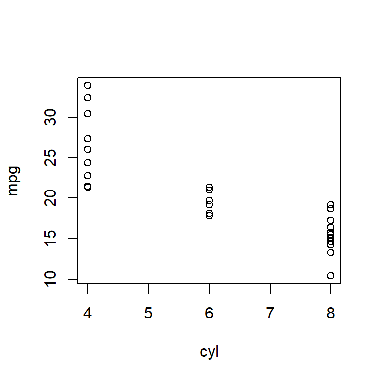

Figure 4.1: Something about cars

````markdown
```{r, fig.cap="Something about cars"}
plot(mpg ~ cyl, data = mtcars)
```
````